# hawksympos

Edgardo L. Rosado Ramos

2025-10-16

# 1. Introduction

This report details the comprehensive analysis of microbiome data from Buccal (oral) and Cloaca (gut) samples of the hawksbill sea turtle from two locations in Puerto Rico (Carite and Sardinera). The objective is to characterize these microbial communities and investigate the influence of body site, geographic location, and turtle size on their composition.

# 2. Data Import and Phyloseq Object Construction

This chunk imports the Mothur output files and the detailed metadata file. It uses a robust method to handle the multi-column metadata, ensuring all variables are correctly loaded.

```r
# --- OTU Table ---
otu_raw <- read.table("final.opti_mcc.0.03.subsample.shared", header = TRUE, sep = "\t")
otu_mat <- t(otu_raw[, -(1:3)])
colnames(otu_mat) <- otu_raw$Group
otu_tab <- otu_table(otu_mat, taxa_are_rows = TRUE)

# --- Taxonomy Table ---
tax_raw <- read.table("final.opti_mcc.0.03.cons.taxonomy", sep = "\t", header = TRUE, quote = "")
taxonomy_strings <- tax_raw$Taxonomy
names(taxonomy_strings) <- tax_raw$OTU
taxonomy_clean <- lapply(strsplit(taxonomy_strings, ";"), function(x) gsub("\\(.*?\\)|\\\"", "", x))
taxonomy_mat <- do.call(rbind, lapply(taxonomy_clean, `length<-`, 7))
colnames(taxonomy_mat) <- c("Kingdom", "Phylum", "Class", "Order", "Family", "Genus", "Species")
rownames(taxonomy_mat) <- names(taxonomy_strings)
tax_tab <- tax_table(as.matrix(taxonomy_mat))

# --- Corrected Metadata Import ---
# This method correctly reads the header and uses the first column for row names.
metadata_df <- read.table("hawkm.design", header = TRUE, row.names = 1, sep = "\t", stringsAsFactors = TRUE)
sample_data_obj <- sample_data(metadata_df)

# --- Combine into a single Phyloseq Object ---
physeq_initial <- phyloseq(otu_tab, tax_tab, sample_data_obj)

print("--- Verification of Imported Metadata ---")
```

```
## [1] "--- Verification of Imported Metadata ---"
```

```r
head(sample_data(physeq_initial))
```

```
##      SampleType  Location size
## F10B     Buccal Sardinera  <80
## F10C     Cloaca Sardinera  <80
## F10X    Control Sardinera  <80
## F11B     Buccal    Carite  >80
## F11C     Cloaca    Carite  >80
## F11X    Control    Carite  >80
```

```r
physeq_corrected <- physeq_initial

# Swap the entire metadata rows
meta_f1b <- sample_data(physeq_corrected)["F1B",]
meta_f1x <- sample_data(physeq_corrected)["F1X",]
sample_data(physeq_corrected)["F1B",] <- meta_f1x
sample_data(physeq_corrected)["F1X",] <- meta_f1b

# This is our final, clean phyloseq object for all subsequent analyses
physeq_final <- physeq_corrected

print("--- Verification of Sample Swap ---")
```

```
## [1] "--- Verification of Sample Swap ---"
```

```r
print(sample_data(physeq_final)[c("F1B", "F1X"), ])
```

```
##      SampleType Location size
## NA         <NA>     <NA> <NA>
## NA.1       <NA>     <NA> <NA>
```

# 4. Analysis by Sample Type (Buccal vs. Cloaca)

This section contains the core biological comparison between the two body sites. We first create a data subset that excludes the control samples.

```r
phyloseq_nocontrol <- subset_samples(physeq_final, SampleType != "Control")
phyloseq_nocontrol <- prune_taxa(taxa_sums(phyloseq_nocontrol) > 0, phyloseq_nocontrol)
```

### 4.1. Alpha Diversity

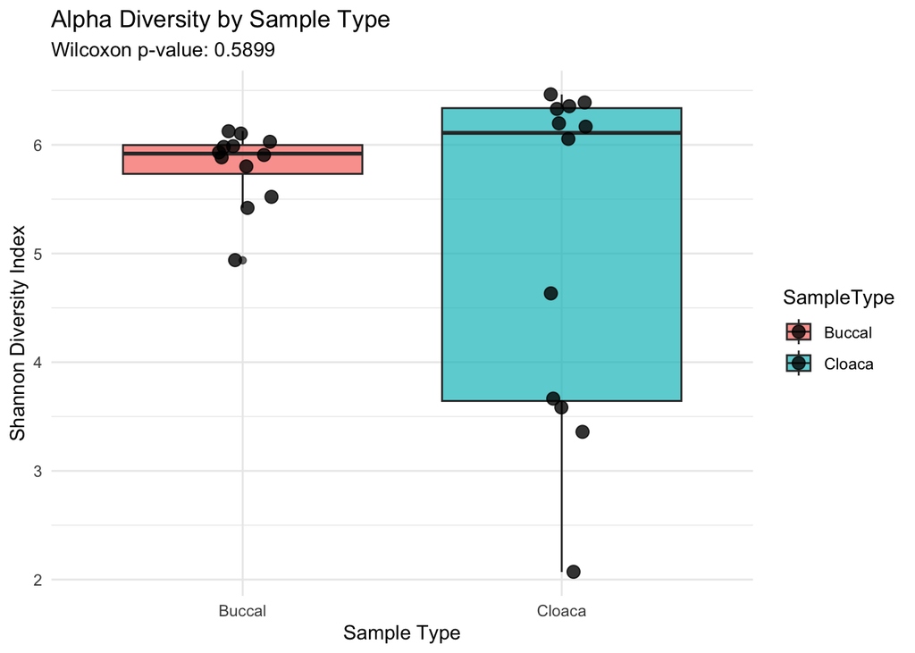

```r
# Calculate and test Shannon diversity
alpha_div <- estimate_richness(phyloseq_nocontrol, measures = "Shannon")
alpha_div$SampleType <- sample_data(phyloseq_nocontrol)$SampleType
stat_test <- wilcox.test(Shannon ~ SampleType, data = alpha_div)

# Visualize
ggplot(alpha_div, aes(x = SampleType, y = Shannon, fill = SampleType)) +
  geom_boxplot(alpha = 0.7) + geom_jitter(width = 0.1, size = 3, alpha = 0.8) +
  theme_minimal() +
  labs(title = "Alpha Diversity by Sample Type",
       subtitle = paste("Wilcoxon p-value:", round(stat_test$p.value, 4)),
       x = "Sample Type", y = "Shannon Diversity Index")
```

**Conclusion:** There is no significant difference in alpha diversity between Buccal and Cloaca samples (p = 0.59).

### 4.2. Beta Diversity

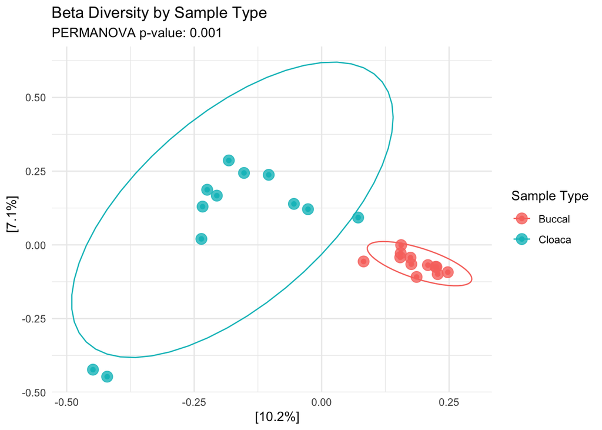

```r
# Normalize, calculate distance, and perform PERMANOVA test
physeq_rel_abund <- transform_sample_counts(phyloseq_nocontrol, function(x) x / sum(x))
bray_dist <- phyloseq::distance(physeq_rel_abund, method = "bray")
permanova_test <- adonis2(bray_dist ~ SampleType, data = as(sample_data(physeq_rel_abund), "data.frame"))
p_val <- permanova_test$`Pr(>F)`[1]

# PCoA Plot
pcoa_ord <- ordinate(physeq_rel_abund, method = "PCoA", distance = bray_dist)
plot_ordination(physeq_rel_abund, pcoa_ord, color = "SampleType") +
  geom_point(size = 4, alpha = 0.8) + stat_ellipse(type = "t") + theme_minimal() +
  labs(title = "Beta Diversity by Sample Type",
       subtitle = paste("PERMANOVA p-value:", round(p_val, 4)), color = "Sample Type")
```

**Conclusion:** There is a highly significant difference in community composition between Buccal and Cloaca samples (p = 0.001).

### 4.3. Differential Abundance (DESeq2) & Heatmap

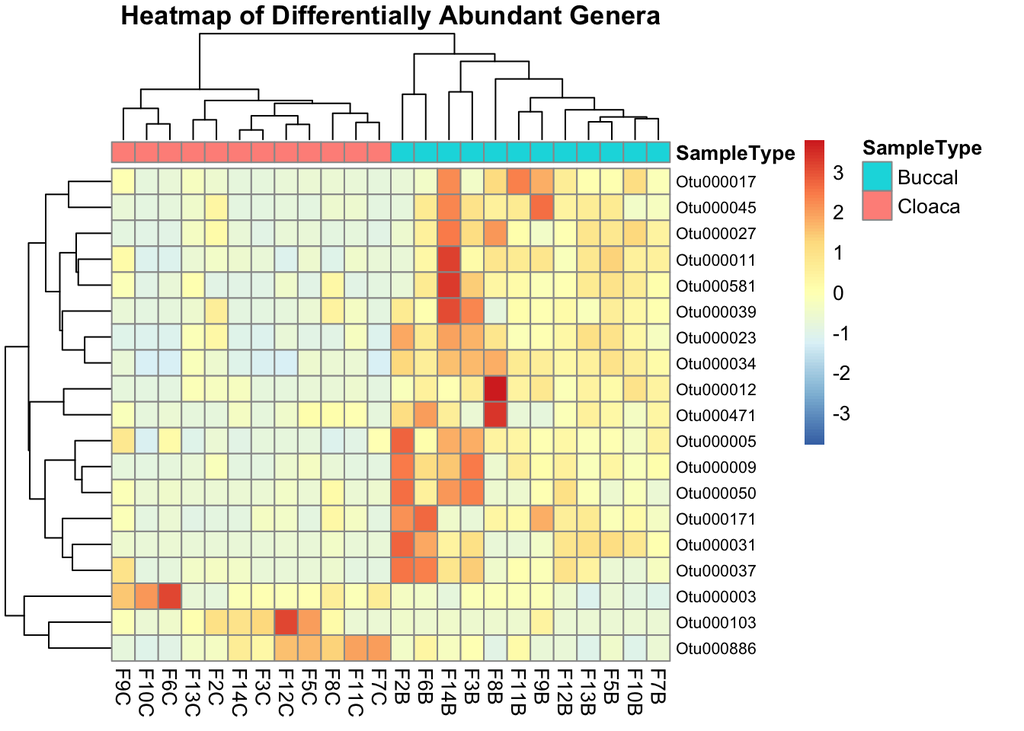

```r
# Pre-filter low abundance genera
genus_level_data <- tax_glom(phyloseq_nocontrol, taxrank = "Genus")
keep_taxa <- taxa_sums(genus_level_data) >= 10
genus_level_data_filtered <- prune_taxa(keep_taxa, genus_level_data)

# Run DESeq2
deseq_obj <- phyloseq_to_deseq2(genus_level_data_filtered, ~ SampleType)
deseq_obj <- DESeq(deseq_obj)
res <- results(deseq_obj, contrast = c("SampleType", "Buccal", "Cloaca"))
res_significant <- subset(res, padj < 0.05)

# Generate Heatmap of significant results
if(nrow(res_significant) > 1) {
  sig_genera_names <- rownames(res_significant)
  rld <- rlog(deseq_obj, blind = FALSE)
  sig_heatmap_mat <- assay(rld)[sig_genera_names, ]

  # Filter for zero-variance rows before plotting
  variances <- apply(sig_heatmap_mat, 1, var)
  sig_heatmap_mat_filtered <- sig_heatmap_mat[variances > 0, ]

  if(nrow(sig_heatmap_mat_filtered) > 1){
      annotation_df <- as.data.frame(colData(deseq_obj)[, "SampleType", drop = FALSE])
      pheatmap(sig_heatmap_mat_filtered,
               annotation_col = annotation_df,
               cluster_rows = TRUE, cluster_cols = TRUE,
               main = "Heatmap of Differentially Abundant Genera",
               fontsize_row = 8, scale = "row")
  } else {
     print("Not enough significant genera with variance to plot a heatmap.")
  }
} else {
  print("No significant genera found to generate a heatmap.")
}
```

# 5. Analysis by Environmental & Host Factors

Now we investigate the influence of the new metadata variables on the microbiome.

### 5.1. Analysis by Location (Carite vs. Sardinera)

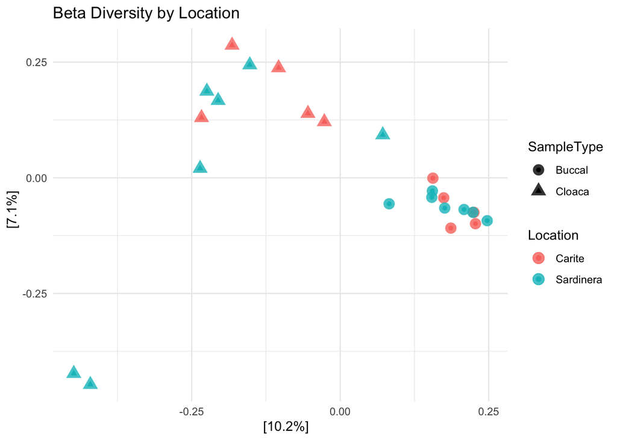

```r
# PCoA Plot Colored by Location
plot_ordination(physeq_rel_abund, pcoa_ord, color = "Location", shape = "SampleType") +
  geom_point(size = 4, alpha = 0.8) +
  theme_minimal() +
  labs(title = "Beta Diversity by Location")
```

```r
# Statistical Test (PERMANOVA)
sample_data_for_test <- as(sample_data(phyloseq_nocontrol), "data.frame")
permanova_location_test <- adonis2(bray_dist ~ Location, data = sample_data_for_test)

print("--- PERMANOVA Test for Location ---")
```

```
## [1] "--- PERMANOVA Test for Location ---"
```

```r
print(permanova_location_test)
```

```
## Permutation test for adonis under reduced model
## Permutation: free
## Number of permutations: 999
##
## adonis2(formula = bray_dist ~ Location, data = sample_data_for_test)
##          Df SumOfSqs     R2     F Pr(>F)
## Model     1   0.4861 0.0453 1.044  0.311
## Residual 22  10.2435 0.9547
## Total    23  10.7296 1.0000
```

### 5.2. Analysis by Turtle Size (‘>80’ vs. ‘<80’)

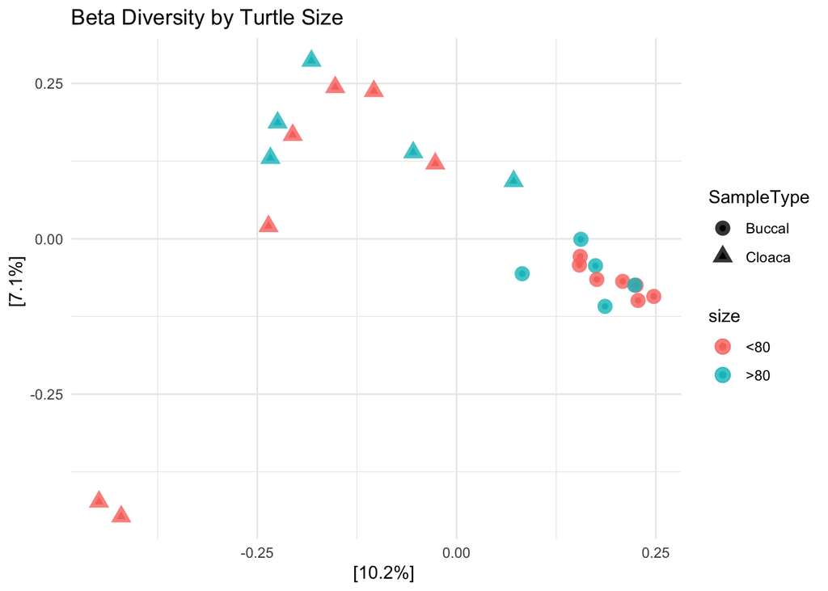

```r
# PCoA Plot Colored by Size
plot_ordination(physeq_rel_abund, pcoa_ord, color = "size", shape = "SampleType") +
  geom_point(size = 4, alpha = 0.8) +
  theme_minimal() +
  labs(title = "Beta Diversity by Turtle Size")
```

```r
# Statistical Test (PERMANOVA)
permanova_size_test <- adonis2(bray_dist ~ size, data = sample_data_for_test)

print("--- PERMANOVA Test for Size ---")
```

```
## [1] "--- PERMANOVA Test for Size ---"
```

```r
print(permanova_size_test)
```

```
## Permutation test for adonis under reduced model
## Permutation: free
## Number of permutations: 999
##
## adonis2(formula = bray_dist ~ size, data = sample_data_for_test)
##          Df SumOfSqs      R2      F Pr(>F)
## Model     1   0.4575 0.04264 0.9798  0.538
## Residual 22  10.2721 0.95736
## Total    23  10.7296 1.00000
```

```r
# --- Multi-Factor PERMANOVA Analysis ---
# This single test evaluates the importance of all variables at once.

# We use the same Bray-Curtis distance matrix as before
# bray_dist <- phyloseq::distance(physeq_rel_abund, method = "bray")

# We use the same metadata data frame
# sample_data_for_test <- as(sample_data(phyloseq_nocontrol), "data.frame")

# The formula now includes all factors. The '*' tests for interactions.
permanova_full_model <- adonis2(bray_dist ~ SampleType * Location * size,
                                data = sample_data_for_test)

print("--- Full Model PERMANOVA Results ---")
```

```
## [1] "--- Full Model PERMANOVA Results ---"
```

```r
print(permanova_full_model)
```

```
## Permutation test for adonis under reduced model
## Permutation: free
## Number of permutations: 999
##
## adonis2(formula = bray_dist ~ SampleType * Location * size, data = sample_data_for_test)
##          Df SumOfSqs      R2      F Pr(>F)
## Model     7   3.7802 0.35232 1.2434  0.001 ***
## Residual 16   6.9493 0.64768
## Total    23  10.7296 1.00000
## ---
## Signif. codes:  0 '***' 0.001 '**' 0.01 '*' 0.05 '.' 0.1 ' ' 1
```

```r
# --- Final Multi-Factor PERMANOVA (by terms) ---
# This is the definitive test for your thesis.
# The only change is adding the 'by = "terms"' argument.

permanova_final_model <- adonis2(bray_dist ~ SampleType * Location * size,
                                 data = sample_data_for_test,
                                 by = "terms")

print("--- Final Model PERMANOVA Results (by Factor) ---")
```

```
## [1] "--- Final Model PERMANOVA Results (by Factor) ---"
```

```r
print(permanova_final_model)
```

```
## Permutation test for adonis under reduced model
## Terms added sequentially (first to last)
## Permutation: free
## Number of permutations: 999
##
## adonis2(formula = bray_dist ~ SampleType * Location * size, data = sample_data_for_test, by = "terms")
##                          Df SumOfSqs      R2      F Pr(>F)
## SampleType                1   0.9760 0.09097 2.2472  0.001 ***
## Location                  1   0.4861 0.04530 1.1191  0.135
## size                      1   0.4400 0.04101 1.0131  0.365
## SampleType:Location       1   0.4849 0.04519 1.1164  0.132
## SampleType:size           1   0.4498 0.04192 1.0356  0.333
## Location:size             1   0.4738 0.04416 1.0909  0.175
## SampleType:Location:size  1   0.4696 0.04377 1.0812  0.206
## Residual                 16   6.9493 0.64768
## Total                    23  10.7296 1.00000
## ---
## Signif. codes:  0 '***' 0.001 '**' 0.01 '*' 0.05 '.' 0.1 ' ' 1
```

```r
# --- 1. Install and Load the decontam Package ---
# You only need to run the installation line once.
if (!requireNamespace("BiocManager", quietly = TRUE))
install.packages("BiocManager")
BiocManager::install("decontam")
library(decontam)

# --- 2. Prepare the Data for decontam ---
# The function needs a column in the metadata that clearly identifies
# which samples are the negative controls.
# We will add a new column called "is_control".
sample_data(physeq_final)$is_control <- sample_data(physeq_final)$SampleType == "Control"

# --- 3. Run the decontam Analysis ---
# We use the prevalence method, identifying contaminants based on whether they are
# more prevalent in control samples than in true samples.
# The threshold of 0.5 is very strict and recommended.
contaminant_df <- isContaminant(physeq_final,
                                method = 'prevalence',
                                neg = "is_control",
                                threshold = 0.5)

# --- 4. Investigate the Results ---
# Let's see how many contaminants were identified.
cat("--- Decontam Analysis Summary ---\n")
```

```
## --- Decontam Analysis Summary ---
```

```r
print(table(contaminant_df$contaminant))
```

```
##
## FALSE  TRUE
## 18645   238
```

```r
# (Optional but recommended) Let's see the taxonomy of the contaminants found.
if(any(contaminant_df$contaminant)) {
  contaminant_genera <- tax_table(physeq_final)[contaminant_df$contaminant, "Genus"]
  cat("\n--- Contaminant Genera Identified ---\n")
  print(unique(contaminant_genera))
}
```

```
##
## --- Contaminant Genera Identified ---
## Taxonomy Table:     [126 taxa by 1 taxonomic ranks]:
##           Genus
## Otu000002 "Acinetobacter"
## Otu000007 "Burkholderia"
## Otu000010 "Sphingomonadales_unclassified"
## Otu000015 "Proteobacteria_unclassified"
## Otu000016 "Chitinophagaceae_unclassified"
## Otu000020 "Staphylococcus"
## Otu000026 "Moraxellaceae_unclassified"
## Otu000029 "Sphingomonadaceae_unclassified"
## Otu000035 "Bacteria_unclassified"
## Otu000040 "Actinomycetales_unclassified"
## Otu000056 "Steroidobacter"
## Otu000064 "Mesorhizobium"
## Otu000073 "Brevundimonas"
## Otu000094 "Afipia"
## Otu000098 "Streptococcus"
## Otu000110 "Sphingomonas"
## Otu000122 "Novosphingobium"
## Otu000123 "Bradyrhizobium"
## Otu000129 "Kineococcus"
## Otu000143 "Paludibacter"
## Otu000145 "Campylobacterales_unclassified"
## Otu000154 "Modestobacter"
## Otu000176 "Microbacteriaceae_unclassified"
## Otu000186 "Rhizobiales_unclassified"
## Otu000195 "Sphingobacteriales_unclassified"
## Otu000199 "Phenylobacterium"
## Otu000202 "Erythrobacter"
## Otu000203 "Rhizobium"
## Otu000206 "Alphaproteobacteria_unclassified"
## Otu000224 "Gammaproteobacteria_unclassified"
## Otu000240 "Pelagibius"
## Otu000242 "Quadrisphaera"
## Otu000248 "Halomonas"
## Otu000253 "Corynebacterium"
## Otu000262 "Saprospiraceae_unclassified"
## Otu000272 "Pseudolabrys"
```

[output cut: 75 more lines]

```
## Otu001131 "Pseudonocardia"
## Otu001144 "Leptotrichia"
## Otu001252 "Marmoricola"
## Otu001275 "Pseudoxanthomonas"
## Otu001425 "Actinopolyspora"
## Otu001452 "Kangiella"
## Otu001883 "Lysinibacillus"
## Otu001891 "Nocardioides"
## Otu001979 "Alcaligenaceae_unclassified"
## Otu002217 "Nocardiaceae_unclassified"
## Otu002613 "Gemmata"
## Otu003330 "Lachnospiraceae_unclassified"
## Otu004033 "Croceicoccus"
## Otu004152 "Bacillaceae_2_unclassified"
## Otu013180 "Gp1"
```

```r
# --- 5. Create the Final, Decontaminated Phyloseq Object ---
# This is the most important step. We filter out the OTUs that were flagged as contaminants.
physeq_decontaminated <- prune_taxa(!contaminant_df$contaminant, physeq_final)


# --- 6. Verification: Check the "Before and After" ---
cat("\n--- Verification of Decontamination ---\n")
```

```
##
## --- Verification of Decontamination ---
```

```r
cat("Original number of taxa:", ntaxa(physeq_final), "\n")
```

```
## Original number of taxa: 18883
```

```r
cat("Number of taxa after decontamination:", ntaxa(physeq_decontaminated), "\n")
```

```
## Number of taxa after decontamination: 18645
```

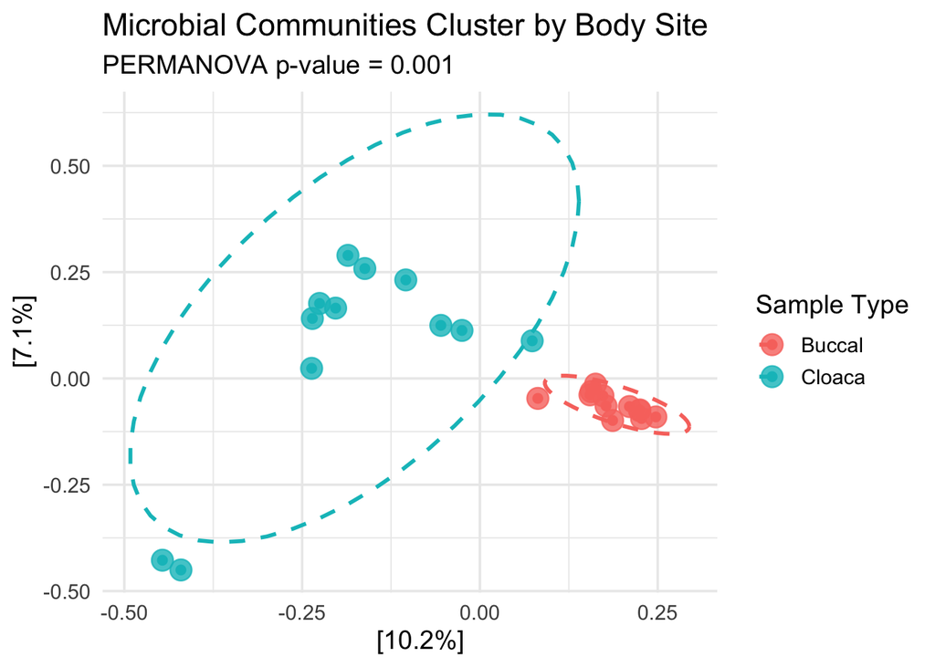

```r
# --- Figure 1: PCoA Plot by SampleType ---
library(ggplot2)
library(phyloseq)

# Create a subset without controls from the decontaminated object
phyloseq_nocontrol <- subset_samples(physeq_decontaminated, SampleType != "Control")
phyloseq_nocontrol <- prune_taxa(taxa_sums(phyloseq_nocontrol) > 0, phyloseq_nocontrol)

# Normalize, calculate distance, and perform ordination
physeq_rel_abund <- transform_sample_counts(phyloseq_nocontrol, function(x) x / sum(x))
bray_dist <- phyloseq::distance(physeq_rel_abund, method = "bray")
pcoa_ord <- ordinate(physeq_rel_abund, method = "PCoA", distance = bray_dist)

# Get the PERMANOVA p-value for the subtitle
permanova_test <- adonis2(bray_dist ~ SampleType, data = as(sample_data(physeq_rel_abund), "data.frame"))
p_val <- permanova_test$`Pr(>F)`[1]

# Create the plot
plot_ordination(physeq_rel_abund, pcoa_ord, color = "SampleType") +
  geom_point(size = 5, alpha = 0.8) +
  stat_ellipse(type = "t", linetype = 2, linewidth = 1) +
  theme_minimal(base_size = 14) +
  labs(
    title = "Microbial Communities Cluster by Body Site",
    subtitle = paste("PERMANOVA p-value =", round(p_val, 3)),
    color = "Sample Type"
  )
```

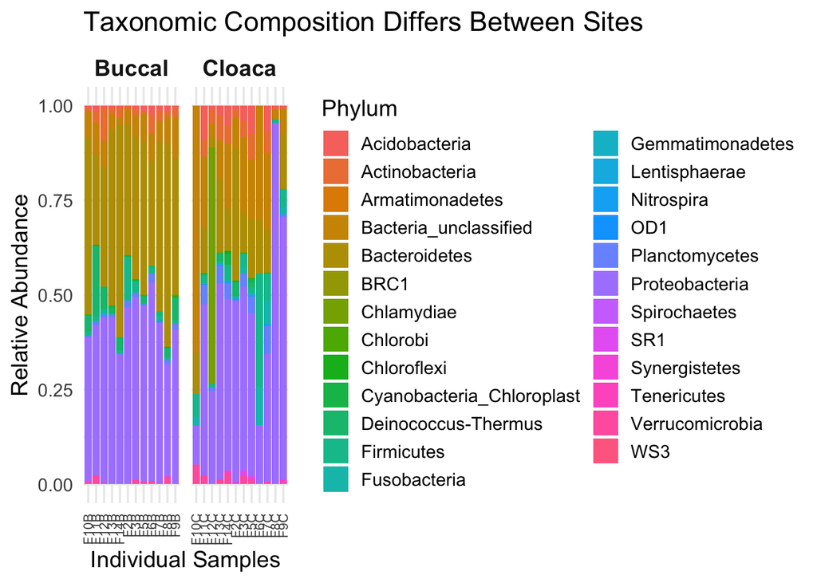

```r
# --- Figure 2: Taxonomic Bar Plot by Phylum ---
library(ggplot2)
library(phyloseq)

# Aggregate data to the Phylum level
phylum_data <- tax_glom(phyloseq_nocontrol, taxrank = "Phylum", NArm = FALSE)
phylum_rel_abund <- transform_sample_counts(phylum_data, function(x) x / sum(x))

# Prepare data for plotting
plot_df <- psmelt(phylum_rel_abund)

# Create the plot
ggplot(plot_df, aes(x = Sample, y = Abundance, fill = Phylum)) +
  geom_bar(stat = "identity") +
  facet_wrap(~SampleType, scales = "free_x", nrow = 1) +
  labs(
    title = "Taxonomic Composition Differs Between Sites",
    x = "Individual Samples",
    y = "Relative Abundance"
  ) +
  theme_minimal(base_size = 14) +
  theme(
    axis.text.x = element_text(angle = 90, hjust = 1, vjust = 0.5, size = 8),
    strip.text = element_text(face = "bold", size = 14)
  )
```

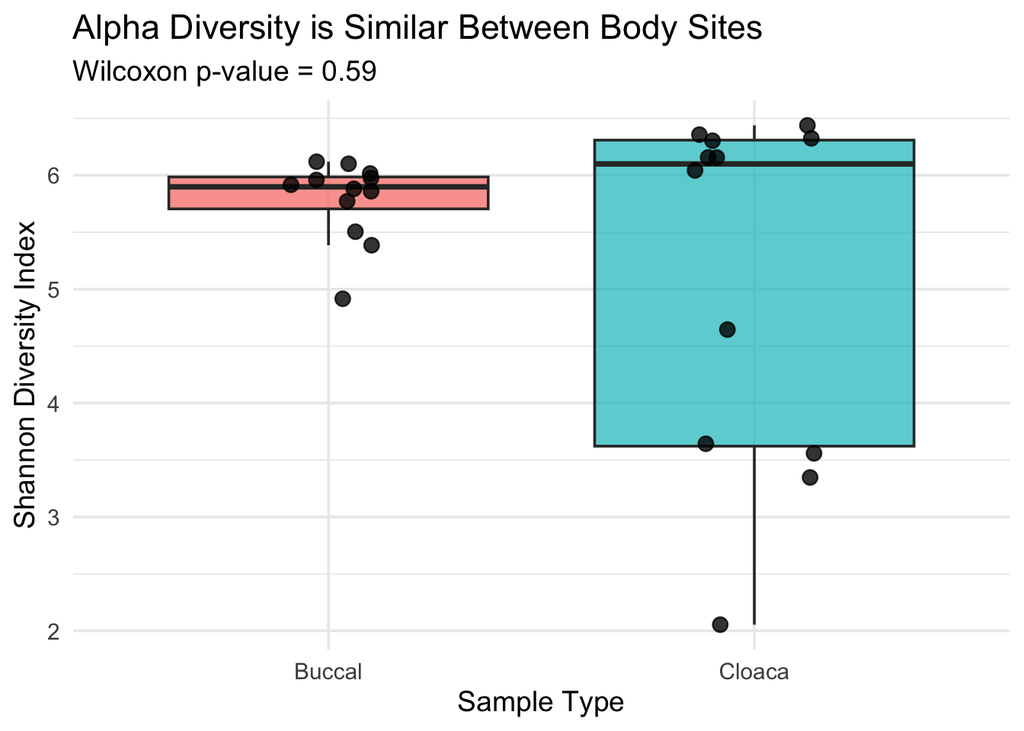

```r
# --- Figure 3: Alpha Diversity Box Plot ---
library(ggplot2)
library(phyloseq)

# Calculate and test Shannon diversity
alpha_div <- estimate_richness(phyloseq_nocontrol, measures = "Shannon")
alpha_div$SampleType <- sample_data(phyloseq_nocontrol)$SampleType
stat_test <- wilcox.test(Shannon ~ SampleType, data = alpha_div)

# Create the plot
ggplot(alpha_div, aes(x = SampleType, y = Shannon, fill = SampleType)) +
  geom_boxplot(alpha = 0.7, outlier.shape = NA) +
  geom_jitter(width = 0.15, size = 3, alpha = 0.8) +
  theme_minimal(base_size = 14) +
  labs(
    title = "Alpha Diversity is Similar Between Body Sites",
    subtitle = paste("Wilcoxon p-value =", round(stat_test$p.value, 3)),
    x = "Sample Type",
    y = "Shannon Diversity Index"
  ) +
  theme(legend.position = "none")
```

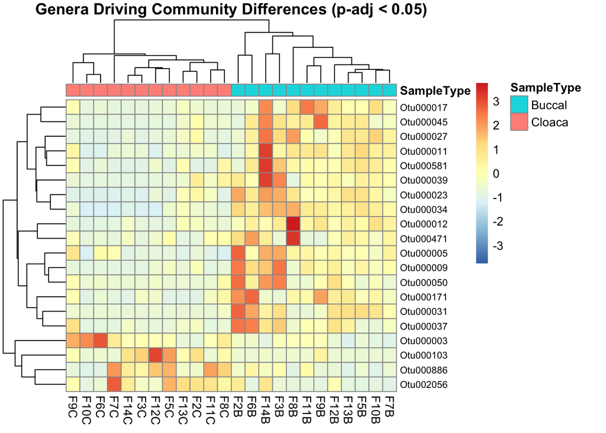

```r
# --- Figure 4: Heatmap of Differentially Abundant Genera ---
library(DESeq2)
library(pheatmap)

# Pre-filter and run DESeq2
genus_level_data <- tax_glom(phyloseq_nocontrol, taxrank = "Genus")
keep_taxa <- taxa_sums(genus_level_data) >= 10
genus_level_data_filtered <- prune_taxa(keep_taxa, genus_level_data)
deseq_obj <- phyloseq_to_deseq2(genus_level_data_filtered, ~ SampleType)
deseq_obj <- DESeq(deseq_obj)
res <- results(deseq_obj, contrast = c("SampleType", "Buccal", "Cloaca"))
res_significant <- subset(res, padj < 0.05)

# Generate Heatmap
if(nrow(res_significant) > 1) {
  sig_genera_names <- rownames(res_significant)
  rld <- rlog(deseq_obj, blind = FALSE)
  sig_heatmap_mat <- assay(rld)[sig_genera_names, ]
  variances <- apply(sig_heatmap_mat, 1, var)
  sig_heatmap_mat_filtered <- sig_heatmap_mat[variances > 0, ]

  if(nrow(sig_heatmap_mat_filtered) > 1){
      annotation_df <- as.data.frame(colData(deseq_obj)[, "SampleType", drop = FALSE])
      pheatmap(sig_heatmap_mat_filtered,
               annotation_col = annotation_df,
               main = "Genera Driving Community Differences (p-adj < 0.05)",
               fontsize_row = 8, scale = "row")
  }
}
```

```r
# --- 1. Isolate the data for just sample F8C ---
physeq_F8C <- subset_samples(phyloseq_nocontrol, sample_names(phyloseq_nocontrol) == "F8C")

# --- 2. Filter this data to only include the Phylum Proteobacteria ---
physeq_F8C_proteo <- subset_taxa(physeq_F8C, Phylum == "Proteobacteria")

# --- 3. Transform to relative abundance ---
physeq_F8C_proteo_rel <- transform_sample_counts(physeq_F8C_proteo, function(x) x / sum(x))

# --- 4. Find the most abundant taxa within this group ---
# We'll use psmelt to convert to a data frame and then sort.
plot_df_F8C <- psmelt(physeq_F8C_proteo_rel)

# Arrange the data frame to see the most abundant taxa at the top
top_taxa_in_F8C <- arrange(plot_df_F8C, desc(Abundance))

# --- 5. Print the Top 5 Most Abundant Proteobacteria in this sample ---
cat("--- Top 5 Most Abundant Proteobacteria Genera in Sample F8C ---\n")
```

```
## --- Top 5 Most Abundant Proteobacteria Genera in Sample F8C ---
```

```r
print(head(top_taxa_in_F8C[, c("Genus", "Family", "Abundance")], 5))
```

```
##                          Genus            Family   Abundance
## 1                 Helicobacter Helicobacteraceae 0.761973875
## 2                 Helicobacter Helicobacteraceae 0.002902758
## 3                 Helicobacter Helicobacteraceae 0.002902758
## 4 Pasteurellaceae_unclassified   Pasteurellaceae 0.001451379
## 5                 Helicobacter Helicobacteraceae 0.001451379
```

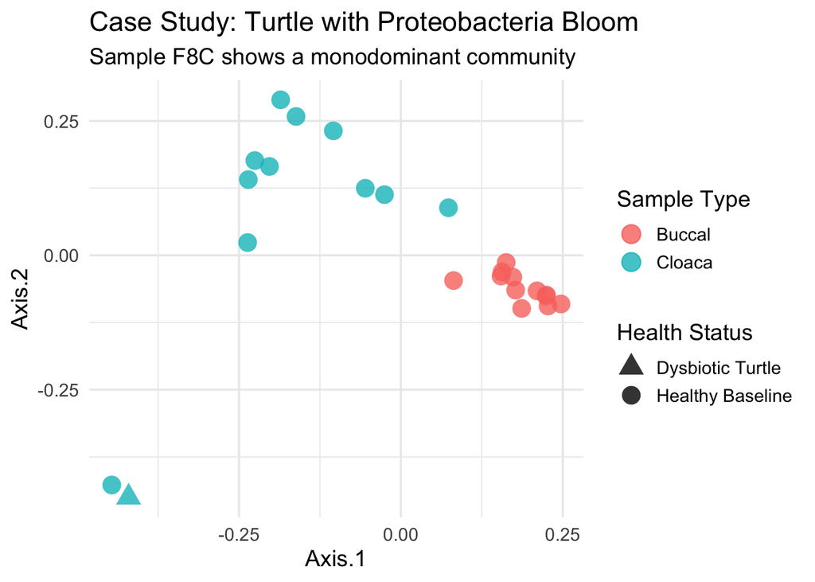

```r
# --- PCoA Plot Highlighting the Dysbiotic Turtle ---
sample_of_interest <- "F8C"

# Create the data for plotting
plot_data <- data.frame(
  pcoa_ord$vectors[, 1:2], # We use the pcoa_ord from your previous beta diversity chunk
  as(sample_data(phyloseq_nocontrol), "data.frame")
)
plot_data$Highlight <- ifelse(rownames(plot_data) == sample_of_interest,
                              "Dysbiotic Turtle", "Healthy Baseline")

# Build the plot
ggplot(plot_data, aes(x = Axis.1, y = Axis.2)) +
  geom_point(aes(color = SampleType, shape = Highlight), size = 5, alpha = 0.8) +
  scale_shape_manual(values = c("Dysbiotic Turtle" = 17, "Healthy Baseline" = 16)) + # Triangle for the outlier
  theme_minimal(base_size = 14) +
  labs(
    title = "Case Study: Turtle with Proteobacteria Bloom",
    subtitle = paste("Sample", sample_of_interest, "shows a monodominant community"),
    color = "Sample Type", shape = "Health Status"
  )
```

```r
# --- 1. Find the OTU ID for the dominant Helicobacter ---
# We know from our previous analysis that the high abundance in F8C was from Helicobacter.
# First, let's get the specific OTU ID for the most abundant Helicobacter in F8C.
physeq_F8C <- subset_samples(phyloseq_nocontrol, sample_names(phyloseq_nocontrol) == "F8C")
physeq_F8C_rel <- transform_sample_counts(physeq_F8C, function(x) x / sum(x))
df_F8C <- psmelt(physeq_F8C_rel)
top_otu_in_F8C <- arrange(df_F8C, desc(Abundance))
otu_id_helicobacter <- top_otu_in_F8C$OTU[1] # This gets the OTU ID of the most abundant taxon

# --- 2. Now, check the abundance of THAT specific OTU in sample F9C ---
# We look at the raw counts from the main phyloseq object.
otu_abundance_in_F9C <- otu_table(phyloseq_nocontrol)[otu_id_helicobacter, "F9C"]

cat("--- Investigation of Helicobacter in Sample F9C ---\n")
```

```
## --- Investigation of Helicobacter in Sample F9C ---
```

```r
cat("The dominant Helicobacter OTU from F8C is:", otu_id_helicobacter, "\n")
```

```
## The dominant Helicobacter OTU from F8C is: Otu000001
```

```r
cat("The raw count of this OTU in sample F9C is:", otu_abundance_in_F9C, "\n")
```

```
## The raw count of this OTU in sample F9C is: 340
```

```r
# --- 1. Load Required Libraries ---
library(phyloseq)
library(ggplot2)
library(vegan)

# --- 2. Prepare the Data: Define the Groups ---
# We start with the clean, decontaminated, no-controls object.
# Create a new metadata column to define our groups for testing.
sample_data(phyloseq_nocontrol)$Health_Status_H <- ifelse(
  sample_names(phyloseq_nocontrol) %in% c("F8C", "F9C"),
  "Helicobacter_Cluster",
  "Healthy_Baseline"
)

# We will only compare within the Cloaca samples.
physeq_cloaca_only <- subset_samples(phyloseq_nocontrol, SampleType == "Cloaca")


# --- 3. PROOF #1: Alpha Diversity Crash (Statistical Test) ---
# Calculate Shannon diversity for all cloaca samples.
alpha_div_cloaca <- estimate_richness(physeq_cloaca_only, measures = "Shannon")
alpha_div_cloaca$Health_Status_H <- sample_data(physeq_cloaca_only)$Health_Status_H

# Perform a Wilcoxon test to see if the diversity is significantly lower.
alpha_test_h <- wilcox.test(Shannon ~ Health_Status_H, data = alpha_div_cloaca)

cat("--- EVIDENCE FOR HELICOBACTER CLUSTER ---\n\n")
```

```
## --- EVIDENCE FOR HELICOBACTER CLUSTER ---
```

```r
cat("--- PROOF #1: Alpha Diversity has Crashed ---\n")
```

[output not shown]

```r
print(alpha_test_h)
```

```
##
##  Wilcoxon rank sum exact test
##
## data:  Shannon by Health_Status_H
## W = 19, p-value = 0.06061
## alternative hypothesis: true location shift is not equal to 0
```

```r
# --- 4. PROOF #2: Community Composition is an Outlier (Statistical Test) ---
# We use a PERMANOVA test on only the cloaca samples.
physeq_cloaca_rel <- transform_sample_counts(physeq_cloaca_only, function(x) x/sum(x))
bray_dist_cloaca <- phyloseq::distance(physeq_cloaca_rel, method = "bray")
permanova_h <- adonis2(bray_dist_cloaca ~ Health_Status_H,
                       data = as(sample_data(physeq_cloaca_only), "data.frame"))

cat("\n--- PROOF #2: Community is a Significant Outlier ---\n")
```

```
##
## --- PROOF #2: Community is a Significant Outlier ---
```

```r
print(permanova_h)
```

```
## Permutation test for adonis under reduced model
## Permutation: free
## Number of permutations: 999
##
## adonis2(formula = bray_dist_cloaca ~ Health_Status_H, data = as(sample_data(physeq_cloaca_only), "data.frame"))
##          Df SumOfSqs      R2      F Pr(>F)
## Model     1   0.7843 0.15049 1.7715  0.011 *
## Residual 10   4.4274 0.84951
## Total    11   5.2117 1.00000
## ---
## Signif. codes:  0 '***' 0.001 '**' 0.01 '*' 0.05 '.' 0.1 ' ' 1
```

```r
# --- 1. Load Libraries and Re-build a Clean Phyloseq Object ---
# This guarantees our data is not corrupted and all objects are fresh.
library(phyloseq)
library(tidyverse)

# OTU Table
otu_raw <- read.table("final.opti_mcc.0.03.subsample.shared", header = TRUE, sep = "\t")
otu_mat <- t(otu_raw[, -(1:3)])
colnames(otu_mat) <- otu_raw$Group
otu_tab <- otu_table(otu_mat, taxa_are_rows = TRUE)

# Taxonomy Table
tax_raw <- read.table("final.opti_mcc.0.03.cons.taxonomy", sep = "\t", header = TRUE, quote = "")
taxonomy_strings <- tax_raw$Taxonomy
names(taxonomy_strings) <- tax_raw$OTU
taxonomy_clean <- lapply(strsplit(taxonomy_strings, ";"), function(x) gsub("\\(.*?\\)|\\\"", "", x))
taxonomy_mat <- do.call(rbind, lapply(taxonomy_clean, `length<-`, 7))
colnames(taxonomy_mat) <- c("Kingdom", "Phylum", "Class", "Order", "Family", "Genus", "Species")
rownames(taxonomy_mat) <- names(taxonomy_strings)
tax_tab <- tax_table(as.matrix(taxonomy_mat))

# Robust Metadata Import
file_lines <- readLines("hawkm.design")
corrected_lines <- gsub(" +", "\t", file_lines)
temp_connection <- textConnection(corrected_lines)
metadata_df <- read.table(temp_connection, header = TRUE, row.names = 1, sep = "\t", stringsAsFactors = TRUE)
close(temp_connection)

# Re-build the phyloseq object
sample_data_obj <- sample_data(metadata_df)
physeq_clean_build <- phyloseq(otu_tab, tax_tab, sample_data_obj)

# --- 2. Analyze the Helicobacter Cluster (F8C and F9C) ---
otu_id_helicobacter <- "Otu000001"
sample_id_h1 <- "F8C"
sample_id_h2 <- "F9C"

# Calculations for F8C
pathogen_count_h1 <- otu_table(physeq_clean_build)[otu_id_helicobacter, sample_id_h1]
total_reads_h1 <- sample_sums(physeq_clean_build)[sample_id_h1]
relative_abundance_h1 <- (pathogen_count_h1 / total_reads_h1) * 100

# Calculations for F9C
pathogen_count_h2 <- otu_table(physeq_clean_build)[otu_id_helicobacter, sample_id_h2]
total_reads_h2 <- sample_sums(physeq_clean_build)[sample_id_h2]
relative_abundance_h2 <- (pathogen_count_h2 / total_reads_h2) * 100

# --- 3. Analyze the Chlamydophila Case (F12C) ---
otu_id_chlamydophila <- "Otu000004"
sample_id_c <- "F12C"

# Calculations for F12C
pathogen_count_c <- otu_table(physeq_clean_build)[otu_id_chlamydophila, sample_id_c]
total_reads_c <- sample_sums(physeq_clean_build)[sample_id_c]
relative_abundance_c <- (pathogen_count_c / total_reads_c) * 100

# --- 4. Print a Clear, Final Report ---
cat("--- QUANTITATIVE PROOF OF PATHOGEN DOMINANCE ---\n\n")
```

```
## --- QUANTITATIVE PROOF OF PATHOGEN DOMINANCE ---
```

```r
cat("--- Case Study 1: Helicobacter Disease Cluster ---\n")
```

```
## --- Case Study 1: Helicobacter Disease Cluster ---
```

```r
cat("Pathogen OTU:", otu_id_helicobacter, "\n")
```

```
## Pathogen OTU: Otu000001
```

```r
cat("--- Turtle F8C ---\n")
```

```
## --- Turtle F8C ---
```

```r
cat("Raw Count:", pathogen_count_h1, "reads\n")
```

```
## Raw Count: 525 reads
```

```r
cat("Total Sample Reads:", total_reads_h1, "reads\n")
```

```
## Total Sample Reads: 728 reads
```

```r
cat("CONCLUSION: Helicobacter makes up", round(relative_abundance_h1, 2), "% of the entire gut community in turtle F8C.\n\n")
```

```
## CONCLUSION: Helicobacter makes up 72.12 % of the entire gut community in turtle F8C.
```

```r
cat("--- Turtle F9C ---\n")
```

```
## --- Turtle F9C ---
```

```r
cat("Raw Count:", pathogen_count_h2, "reads\n")
```

```
## Raw Count: 340 reads
```

```r
cat("Total Sample Reads:", total_reads_h2, "reads\n")
```

```
## Total Sample Reads: 728 reads
```

```r
cat("CONCLUSION: The same Helicobacter OTU makes up", round(relative_abundance_h2, 2), "% of the entire gut community in turtle F9C.\n\n")
```

```
## CONCLUSION: The same Helicobacter OTU makes up 46.7 % of the entire gut community in turtle F9C.
```

```r
cat("--- Case Study 2: Chlamydophila Dysbiosis in Turtle F12C ---\n")
```

```
## --- Case Study 2: Chlamydophila Dysbiosis in Turtle F12C ---
```

```r
cat("Pathogen OTU:", otu_id_chlamydophila, "\n")
```

```
## Pathogen OTU: Otu000004
```

```r
cat("Raw Count in F12C:", pathogen_count_c, "reads\n")
```

```
## Raw Count in F12C: 348 reads
```

```r
cat("Total Reads in Sample F12C:", total_reads_c, "reads\n")
```

```
## Total Reads in Sample F12C: 728 reads
```

```r
cat("CONCLUSION: Chlamydophila makes up", round(relative_abundance_c, 2), "% of the entire gut community in this turtle.\n")
```

```
## CONCLUSION: Chlamydophila makes up 47.8 % of the entire gut community in this turtle.
```